# Predictive analysis of Bank Marketing

Problem Statement  
The data is related with direct marketing campaigns of a Portuguese banking institution. The marketing campaigns were based on phone calls. Often, more than one contact to the same client was required, in order to access if the product (bank term deposit) would be ('yes') or not ('no') subscribed.

What to achieve?  
The classification goal is to predict if the client will subscribe a term deposit (variable Target).

```python
# To enable plotting graphs in Jupyter notebook
%matplotlib inline

# Ignore warnings
import warnings
warnings.filterwarnings('ignore')
```

```python
# import the common libraries for mathematical and data frames
import pandas as pd
import numpy as np

#statistical data libraries
from numpy import mean
from numpy import std

#for visualization
import matplotlib.pyplot as plt
import seaborn as sns

import plotly.plotly as py
import plotly.figure_factory as ff

# some useful stuff from stats scipy
import scipy.stats as stats

# import labelencoder
from sklearn.preprocessing import LabelEncoder
# import Standard scaler to scale the numeric fields as mentioned above in the description
from sklearn.preprocessing import StandardScaler
# to impute the missing values
from sklearn.impute import SimpleImputer
```

```python
#set the basic figure size and pallete
plt.figure(figsize=(10,15))

sns.set()
pal = sns.hls_palette(8, l=.3, s=.8)
sns.set_palette(pal)
```

```python
#read data into a data frame
dfTermDeposit = pd.read_csv("bank-full.csv")
```

```python
#check the number of rows, columns and dataypes of each column using the info()
dfTermDeposit.info()
```

```
<class 'pandas.core.frame.DataFrame'>
RangeIndex: 45211 entries, 0 to 45210
Data columns (total 17 columns):
age          45211 non-null int64
job          45211 non-null object
marital      45211 non-null object
education    45211 non-null object
default      45211 non-null object
balance      45211 non-null int64
housing      45211 non-null object
loan         45211 non-null object
contact      45211 non-null object
day          45211 non-null int64
month        45211 non-null object
duration     45211 non-null int64
campaign     45211 non-null int64
pdays        45211 non-null int64
previous     45211 non-null int64
poutcome     45211 non-null object
Target       45211 non-null object
dtypes: int64(7), object(10)
memory usage: 5.9+ MB
```

# Attributes Description:

Input variables:

# i. bank client data:

1 - **age:** (numeric)  
2 - **job:** type of job (categorical: 'admin.','blue-collar','entrepreneur','housemaid','management','retired','self-employed','services','student','technician','unemployed','unknown')  
3 - **marital:** marital status (categorical: 'divorced','married','single','unknown'; note: 'divorced' means divorced or widowed)  
4 - **education:** (categorical: primary, secondary, tertiary and unknown)  
5 - **default:** has credit in default? (categorical: 'no','yes','unknown')  
6 - **housing:** has housing loan? (categorical: 'no','yes','unknown')  
7 - **loan:** has personal loan? (categorical: 'no','yes','unknown')  
8 - **balance:** Balance of the individual.

# ii. Related with the last contact of the current campaign:

9 - **contact:** contact communication type (categorical: 'cellular','telephone')  
10 - **month:** last contact month of year (categorical: 'jan', 'feb', 'mar', ..., 'nov', 'dec')  
11 - **day:** last contact day of the week (categorical: 'mon','tue','wed','thu','fri')  
12 - **duration:** last contact duration, in seconds (numeric). Important note: this attribute highly affects the output target (e.g., if duration=0 then y='no'). Yet, the duration is not known before a call is performed. Also, after the end of the call y is obviously known. Thus, this input should only be included for benchmark purposes and should be discarded if the intention is to have a realistic predictive model.

# iii. other attributes:

13 - **campaign:** number of contacts performed during this campaign and for this client (numeric, includes last contact)  
14 - **pdays:** number of days that passed by after the client was last contacted from a previous campaign (numeric; 999 means client was not previously contacted)  
15 - **previous:** number of contacts performed before this campaign and for this client (numeric)  
16 - **poutcome:** outcome of the previous marketing campaign (categorical: 'failure','nonexistent','success')

Output variable (desired target):  
17 - **Target** - has the client subscribed a term deposit? (binary: 'yes','no')

```python
dfTermDeposit.head()
```

|  | age | job | marital | education | default | balance | housing | loan | contact | day | month | duration | campaign | pdays | previous | poutcome | Target |
| --- | --- | --- | --- | --- | --- | --- | --- | --- | --- | --- | --- | --- | --- | --- | --- | --- | --- |
| 0 | 58 | management | married | tertiary | no | 2143 | yes | no | unknown | 5 | may | 261 | 1 | -1 | 0 | unknown | no |
| 1 | 44 | technician | single | secondary | no | 29 | yes | no | unknown | 5 | may | 151 | 1 | -1 | 0 | unknown | no |
| 2 | 33 | entrepreneur | married | secondary | no | 2 | yes | yes | unknown | 5 | may | 76 | 1 | -1 | 0 | unknown | no |
| 3 | 47 | blue-collar | married | unknown | no | 1506 | yes | no | unknown | 5 | may | 92 | 1 | -1 | 0 | unknown | no |
| 4 | 33 | unknown | single | unknown | no | 1 | no | no | unknown | 5 | may | 198 | 1 | -1 | 0 | unknown | no |

```python
#check for any null values
dfTermDeposit.isna().sum()
```

```
age          0
job          0
marital      0
education    0
default      0
balance      0
housing      0
loan         0
contact      0
day          0
month        0
duration     0
campaign     0
pdays        0
previous     0
poutcome     0
Target       0
dtype: int64
```

There are no **missing values**

But few categorical columns have the **unknown** values, which I will be goign to make it NaN and then will compute the values

```python
dfTermDeposit_NoUnknown = dfTermDeposit.replace('unknown',np.nan)
```

```python
dfTermDeposit_NoUnknown.isnull().sum()
```

```
age              0
job            288
marital          0
education     1857
default          0
balance          0
housing          0
loan             0
contact      13020
day              0
month            0
duration         0
campaign         0
pdays            0
previous         0
poutcome     36959
Target           0
dtype: int64
```

```python
# but their are unknown values in the categorical variables. We should replace it by most frequently used i.e. MODE
imputer = SimpleImputer(missing_values=np.nan, strategy='most_frequent')
```

```python
dfTermDeposit_NoUnknown['contact'] = imputer.fit_transform(dfTermDeposit_NoUnknown[['contact']])
dfTermDeposit_NoUnknown['education'] = imputer.fit_transform(dfTermDeposit_NoUnknown[['education']])
dfTermDeposit_NoUnknown['job'] = imputer.fit_transform(dfTermDeposit_NoUnknown[['job']])
dfTermDeposit_NoUnknown['poutcome'] = imputer.fit_transform(dfTermDeposit_NoUnknown[['poutcome']])
```

```python
dfTermDeposit_NoUnknown.isnull().sum()
```

```
age          0
job          0
marital      0
education    0
default      0
balance      0
housing      0
loan         0
contact      0
day          0
month        0
duration     0
campaign     0
pdays        0
previous     0
poutcome     0
Target       0
dtype: int64
```

So now we dont have **unknown** nor **NaN**. All data is cleared and imputed with MODE value as all such columns ver categorical and had a definite list of values in it.

# Exploratory data quality report reflecting the following

```python
#get the basic statistic data of the complete dataset
dfTermDeposit_NoUnknown.describe().T
```

|  | count | mean | std | min | 25% | 50% | 75% | max |
| --- | --- | --- | --- | --- | --- | --- | --- | --- |
| age | 45211.0 | 40.936210 | 10.618762 | 18.0 | 33.0 | 39.0 | 48.0 | 95.0 |
| balance | 45211.0 | 1362.272058 | 3044.765829 | -8019.0 | 72.0 | 448.0 | 1428.0 | 102127.0 |
| day | 45211.0 | 15.806419 | 8.322476 | 1.0 | 8.0 | 16.0 | 21.0 | 31.0 |
| duration | 45211.0 | 258.163080 | 257.527812 | 0.0 | 103.0 | 180.0 | 319.0 | 4918.0 |
| campaign | 45211.0 | 2.763841 | 3.098021 | 1.0 | 1.0 | 2.0 | 3.0 | 63.0 |
| pdays | 45211.0 | 40.197828 | 100.128746 | -1.0 | -1.0 | -1.0 | -1.0 | 871.0 |
| previous | 45211.0 | 0.580323 | 2.303441 | 0.0 | 0.0 | 0.0 | 0.0 | 275.0 |

Mean Age is aproximately 41 years old. (Minimum: 18 years old and Maximum: 95 years old.)

The mean balance is 1,362. However, the Standard Deviation (std) is a high number so we can understand through this that the balance is heavily distributed across the dataset.

Similarly duration is right skewed and mean > median. Minimum values goes from 0 to max value 4918

Pdays has min and median = -1 but max goign to 871, with a mean of 40. This is also right skewed data

**Note**: There are not that much insights we can gain from the descriptive dataset since most of our descriptive data is located not in the "numeric" columns but in the "categorical columns".

# Univariate, Bivariate and MultiVariate Analysis on the Numerical Columns

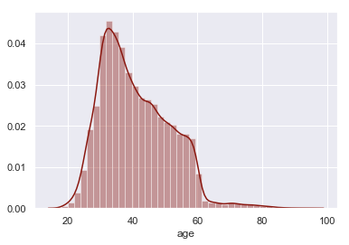

```python
# Age column
sns.distplot(dfTermDeposit_NoUnknown.age.dropna(), kde=True, bins = 39);
```

A positively skewed shape, not a continuously increasing one.

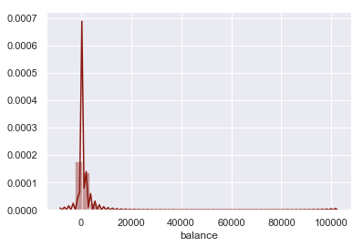

```python
# Balance column
sns.distplot(dfTermDeposit_NoUnknown.balance.dropna(), kde=True, bins = 39);
```

balance has a big spike then gradually fading towards right, but we can see values very close the balance axis running till 100000

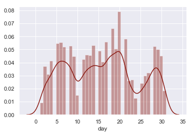

```python
# Day column
sns.distplot(dfTermDeposit.day.dropna(), kde=True, bins = 39);
```

it appears that after every gap of 4-6 days the customer is reached out for the campaign. Also see a sudden spike on day = 20th. seems that to meet target lot of calls are done to increase the Term Deposit accpetance

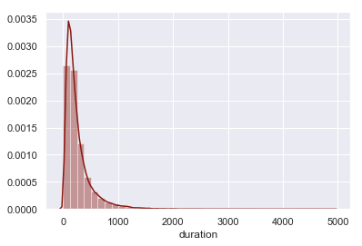

```python
# Duration column
sns.distplot(dfTermDeposit_NoUnknown.duration.dropna(), kde=True, bins = 39);
```

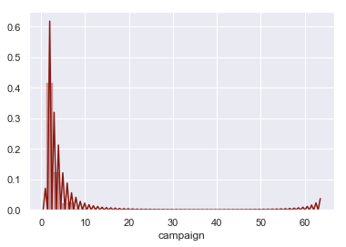

```python
# Campaign column
sns.distplot(dfTermDeposit_NoUnknown.campaign.dropna(), kde=True, bins = 39);
```

less than 10 campaigns are atleast done for all customers, and gradually diminishes.

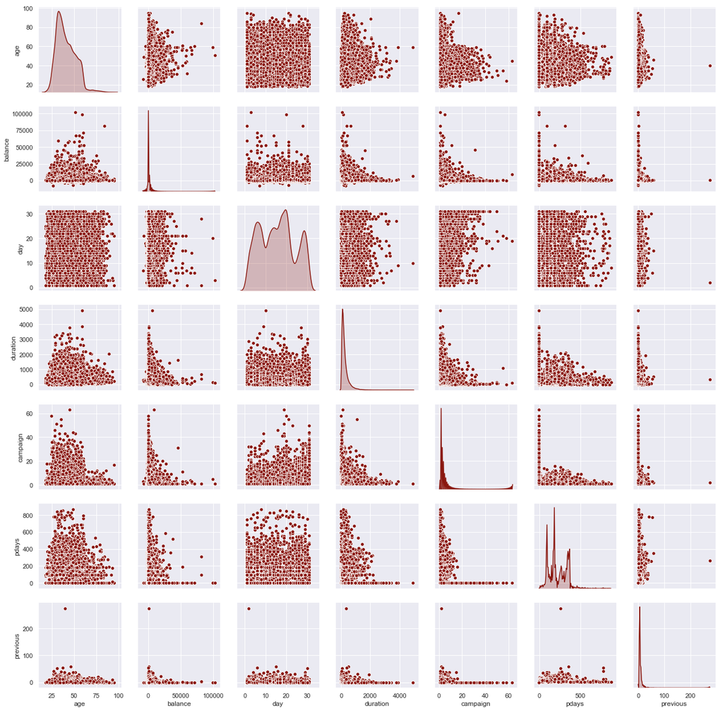

```python
# pairplot on numeric fields
plt.figure(figsize=(14, 14))

sns.pairplot(dfTermDeposit_NoUnknown, diag_kind='kde');
```

We observe the following insights

All the columns of interests (i.e diagonal plot) has the predictive power (as none of them are uniform).

**Before plotting the corrleation matrix, lets see the pairplot against the Target also**

[figure not shown]

```python
# lets draw the pairplot using the target, and see how the outcome is related to these numeric fields

sns.set(style="ticks")

sns.pairplot(dfTermDeposit_NoUnknown, hue="Target", palette="Set1")
plt.show()
```

Looking at the diagonal, Age shows multiple gaussians agaisnt each value of the Target column

For the balance data, there is one spike only and then line merging with x-axis, for both the Target columns

Day column has again many Gaussians for each value of the Target column

Duration has clean one Gaussian against both values of Target

Many small spike Gaussians in the campaign column

Preious appears to have no Gaussian for the No Target value

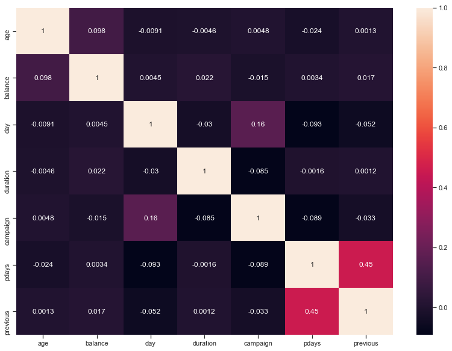

```python
# drawing on numeric columns

plt.figure(figsize=(14, 10))

num_cols = ['age', 'balance', 'day', 'duration', 'campaign', 'pdays', 'previous']

dfTermDeposit_NoUnknown_corr = dfTermDeposit_NoUnknown.corr()
sns.heatmap(dfTermDeposit_NoUnknown_corr,
            xticklabels = dfTermDeposit_NoUnknown_corr.columns.values,
            yticklabels = dfTermDeposit_NoUnknown_corr.columns.values,
            annot = True);
```

We note that:

As per the pairplot, and heatmap, observations as follow:

Data is non-linear, asymmetric

Hence selection of features will not depend upon correlation factor.

Also not a single feature is correlated completely with class, hence requires understanding of combinantion of features.

```python
# Lets drop pdays and will use previous
dfTermDeposit_NoUnknown.drop('pdays', axis=1, inplace=True)
dfTermDeposit_NoUnknown.head()
```

|  | age | job | marital | education | default | balance | housing | loan | contact | day | month | duration | campaign | previous | poutcome | Target |
| --- | --- | --- | --- | --- | --- | --- | --- | --- | --- | --- | --- | --- | --- | --- | --- | --- |
| 0 | 58 | management | married | tertiary | no | 2143 | yes | no | cellular | 5 | may | 261 | 1 | 0 | failure | no |
| 1 | 44 | technician | single | secondary | no | 29 | yes | no | cellular | 5 | may | 151 | 1 | 0 | failure | no |
| 2 | 33 | entrepreneur | married | secondary | no | 2 | yes | yes | cellular | 5 | may | 76 | 1 | 0 | failure | no |
| 3 | 47 | blue-collar | married | secondary | no | 1506 | yes | no | cellular | 5 | may | 92 | 1 | 0 | failure | no |
| 4 | 33 | blue-collar | single | secondary | no | 1 | no | no | cellular | 5 | may | 198 | 1 | 0 | failure | no |

# Univariate and Bivariate Analysis on the Catagorical Columns

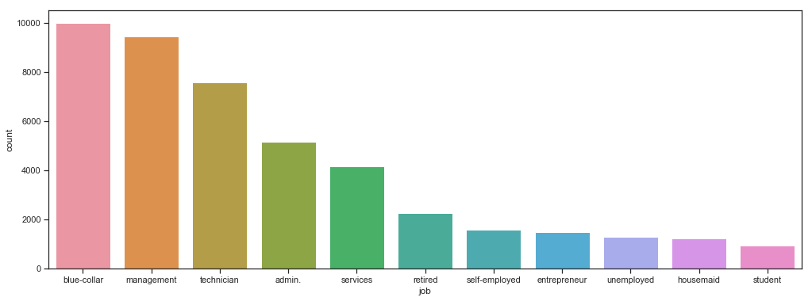

```python
plt.figure(figsize=(17, 6))
sns.countplot(dfTermDeposit_NoUnknown.job.dropna(), order = dfTermDeposit_NoUnknown.job.value_counts().index);
```

This data contains more records for the working class compared to unemployed, housemaid and students. Which if we see are less keen to take Term Deposit in below visualizations

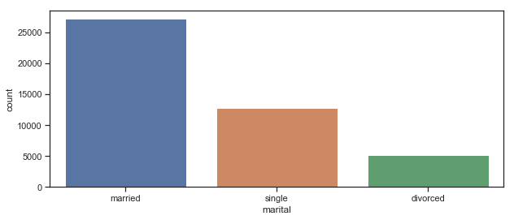

```python
plt.figure(figsize=(10, 4))
sns.countplot(dfTermDeposit_NoUnknown.marital.dropna(), order = dfTermDeposit_NoUnknown.marital.value_counts().index);
```

Dataset contains more information about the married people compared to the single and divorced. It appears that campaign is targeted towards the married customers

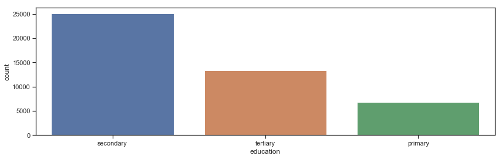

```python
plt.figure(figsize=(14, 4))
sns.countplot(dfTermDeposit_NoUnknown.education.dropna(), order = dfTermDeposit_NoUnknown.education.value_counts().index);
```

In terms of education we have more data for the secondary passed people compared to tertiary. Primary is low comapred to all of them

**Now lets study these categorical data against the target column and conclude any relationships**

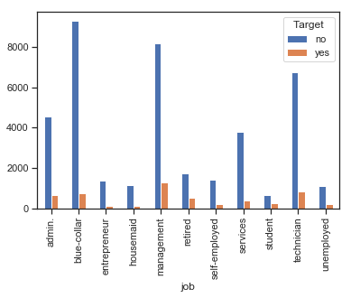

```python
jobTD = pd.crosstab(dfTermDeposit_NoUnknown.job, dfTermDeposit_NoUnknown.Target)
jobTD.plot.bar()
```

**Note:** management, blue collar, technician and admin are the ones who opt for the Term Deposit. Entrpreneur and hosuemaids are the least

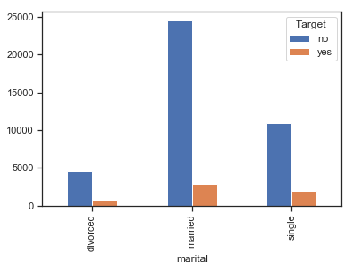

```python
maritalTD = pd.crosstab(dfTermDeposit_NoUnknown.marital, dfTermDeposit_NoUnknown.Target)
maritalTD.plot.bar()
```

**Note:** married and single customers are more liable to take the Term Deposit

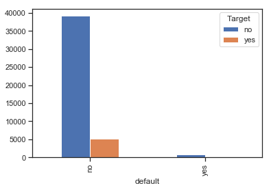

```python
defaultTD = pd.crosstab(dfTermDeposit_NoUnknown.default, dfTermDeposit_NoUnknown.Target)
defaultTD.plot.bar()
```

**Note :** people with no credit default take higher Term Deposits, and nil if they have credit default

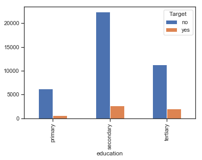

```python
educationTD = pd.crosstab(dfTermDeposit_NoUnknown.education, dfTermDeposit_NoUnknown.Target)
educationTD.plot.bar()
```

**Note :** cusomters holding the secondary opt for Term Deposit higher compared to the ones holding the tertiary

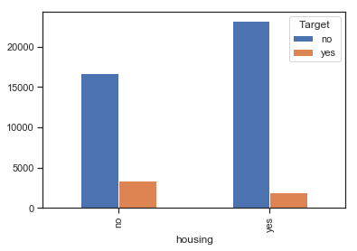

```python
housingTD = pd.crosstab(dfTermDeposit_NoUnknown.housing, dfTermDeposit_NoUnknown.Target)
housingTD.plot.bar()
```

**Note :** Customers having no housing loan opt for more Term Deposit

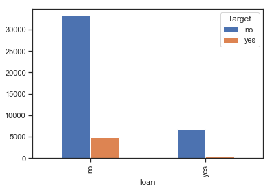

```python
loanTD = pd.crosstab(dfTermDeposit_NoUnknown.loan, dfTermDeposit_NoUnknown.Target)
loanTD.plot.bar()
```

**Note :** Customers having no personal loan opt for Term Deposit

# Convert the Categorical Data to Numeric

```python
#lets make a copy of the above dataset and work on that down the line
dfTransformed = dfTermDeposit_NoUnknown.copy()
dfTransformed.head()
```

|  | age | job | marital | education | default | balance | housing | loan | contact | day | month | duration | campaign | previous | poutcome | Target |
| --- | --- | --- | --- | --- | --- | --- | --- | --- | --- | --- | --- | --- | --- | --- | --- | --- |
| 0 | 58 | management | married | tertiary | no | 2143 | yes | no | cellular | 5 | may | 261 | 1 | 0 | failure | no |
| 1 | 44 | technician | single | secondary | no | 29 | yes | no | cellular | 5 | may | 151 | 1 | 0 | failure | no |
| 2 | 33 | entrepreneur | married | secondary | no | 2 | yes | yes | cellular | 5 | may | 76 | 1 | 0 | failure | no |
| 3 | 47 | blue-collar | married | secondary | no | 1506 | yes | no | cellular | 5 | may | 92 | 1 | 0 | failure | no |
| 4 | 33 | blue-collar | single | secondary | no | 1 | no | no | cellular | 5 | may | 198 | 1 | 0 | failure | no |

```python
# instantiate labelencoder object
le = LabelEncoder()
# Categorical boolean mask
categorical_feature_mask = dfTransformed.dtypes==object
# filter categorical columns using mask and turn it into a list
categorical_cols = dfTransformed.columns[categorical_feature_mask].tolist()
```

```python
# apply le on categorical feature columns
dfTransformed[categorical_cols] = dfTransformed[categorical_cols].apply(lambda col: le.fit_transform(col))
dfTransformed[categorical_cols].head()
```

|  | job | marital | education | default | housing | loan | contact | month | poutcome | Target |
| --- | --- | --- | --- | --- | --- | --- | --- | --- | --- | --- |
| 0 | 4 | 1 | 2 | 0 | 1 | 0 | 0 | 8 | 0 | 0 |
| 1 | 9 | 2 | 1 | 0 | 1 | 0 | 0 | 8 | 0 | 0 |
| 2 | 2 | 1 | 1 | 0 | 1 | 1 | 0 | 8 | 0 | 0 |
| 3 | 1 | 1 | 1 | 0 | 1 | 0 | 0 | 8 | 0 | 0 |
| 4 | 1 | 2 | 1 | 0 | 0 | 0 | 0 | 8 | 0 | 0 |

**Note:** Month column has been wrongly coded by the label encoder, we need to clean this data now

```python
#get this list from the original dataset
lst = [dfTermDeposit_NoUnknown]

# Create a column with the numeric values of the months.
for column in lst:
    column.loc[column["month"] == "jan", "month"] = 1
    column.loc[column["month"] == "feb", "month"] = 2
    column.loc[column["month"] == "mar", "month"] = 3
    column.loc[column["month"] == "apr", "month"] = 4
    column.loc[column["month"] == "may", "month"] = 5
    column.loc[column["month"] == "jun", "month"] = 6
    column.loc[column["month"] == "jul", "month"] = 7
    column.loc[column["month"] == "aug", "month"] = 8
    column.loc[column["month"] == "sep", "month"] = 9
    column.loc[column["month"] == "oct", "month"] = 10
    column.loc[column["month"] == "nov", "month"] = 11
    column.loc[column["month"] == "dec", "month"] = 12

# Change datatype from int32 to int64
dfTransformed["month"] = dfTermDeposit_NoUnknown["month"].astype(np.int64)
dfTransformed.head()
```

|  | age | job | marital | education | default | balance | housing | loan | contact | day | month | duration | campaign | previous | poutcome | Target |
| --- | --- | --- | --- | --- | --- | --- | --- | --- | --- | --- | --- | --- | --- | --- | --- | --- |
| 0 | 58 | 4 | 1 | 2 | 0 | 2143 | 1 | 0 | 0 | 5 | 5 | 261 | 1 | 0 | 0 | 0 |
| 1 | 44 | 9 | 2 | 1 | 0 | 29 | 1 | 0 | 0 | 5 | 5 | 151 | 1 | 0 | 0 | 0 |
| 2 | 33 | 2 | 1 | 1 | 0 | 2 | 1 | 1 | 0 | 5 | 5 | 76 | 1 | 0 | 0 | 0 |
| 3 | 47 | 1 | 1 | 1 | 0 | 1506 | 1 | 0 | 0 | 5 | 5 | 92 | 1 | 0 | 0 | 0 |
| 4 | 33 | 1 | 2 | 1 | 0 | 1 | 0 | 0 | 0 | 5 | 5 | 198 | 1 | 0 | 0 | 0 |

```python
dfTransformed.info()
```

```
<class 'pandas.core.frame.DataFrame'>
RangeIndex: 45211 entries, 0 to 45210
Data columns (total 16 columns):
age          45211 non-null int64
job          45211 non-null int32
marital      45211 non-null int32
education    45211 non-null int32
default      45211 non-null int32
balance      45211 non-null int64
housing      45211 non-null int32
loan         45211 non-null int32
contact      45211 non-null int32
day          45211 non-null int64
month        45211 non-null int64
duration     45211 non-null int64
campaign     45211 non-null int64
previous     45211 non-null int64
poutcome     45211 non-null int32
Target       45211 non-null int32
dtypes: int32(9), int64(7)
memory usage: 4.0 MB
```

**Month Column Analysis**

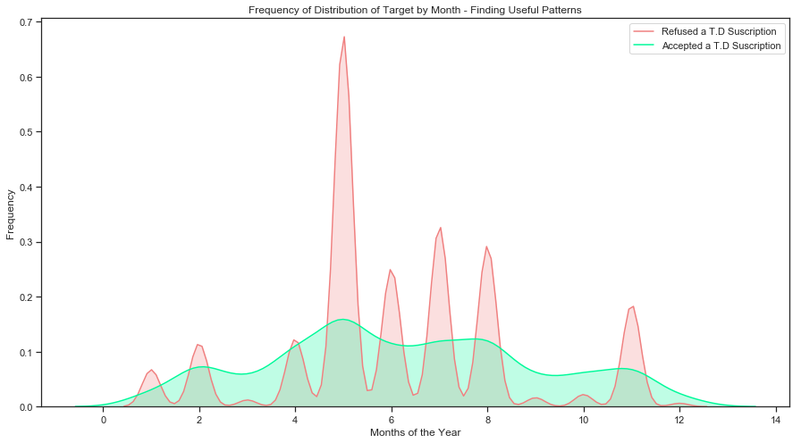

```python
fig = plt.figure(figsize=(15,8),)
ax=sns.kdeplot(dfTransformed.loc[(dfTransformed['Target'] == 0),'month'] , color='#F08080',
               shade=True,label='Refused a T.D Suscription')
ax=sns.kdeplot(dfTransformed.loc[(dfTransformed['Target'] == 1),'month'] , color='#00FA9A',
               shade=True, label='Accepted a T.D Suscription')
ax.set(xlabel='Months of the Year', ylabel='Frequency')
plt.title('Frequency of Distribution of Target by Month - Finding Useful Patterns')
```

**Month column with Target shows that during May month the term deposit is higher**

**Age alone as independent doesnt say much except that people with age from 30 to 50 can easliy take term deposit.**

But we should club Age with Education and Job, probably then we can see any trend

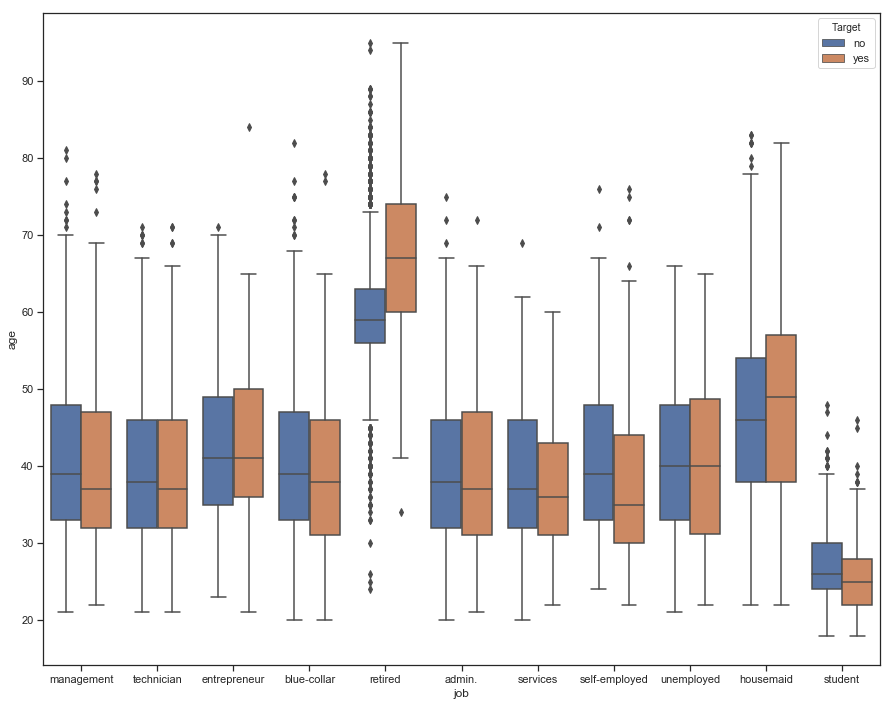

[figure not shown]

```python
fig, ax = plt.subplots(figsize=(15, 12),)
ax = sns.catplot(x="job", y="age", hue="Target", kind="box", data=dfTermDeposit_NoUnknown, ax=ax);
```

**Outliers** - we can see in the above box plot, the outliers spreading below and above the whiskers. Same happens for the numerical features also as seen in the pairplot

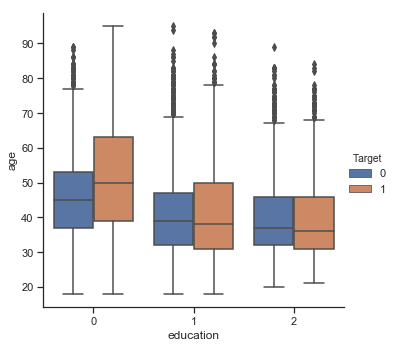

```python
sns.catplot(x="education", y="age", hue="Target", kind="box", data=dfTransformed);
```

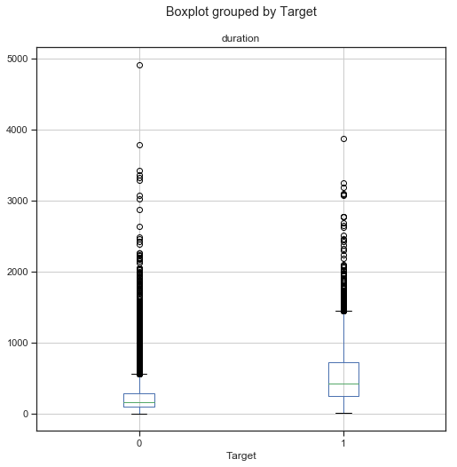

```python
dfTransformed.boxplot(column="duration",        # Column to plot
                 by= "Target",         # Column to split upon
                 figsize= (8,8))        # Figure size
```

Maximum duration spent on a customer helps in converting them to accept the term deposit. This is clearly visible from the box plot above where the Target = yes has a longer box plot and whisker comvering the much higher duration then the Target = no